# Problem Set 3

Anthony Fontana

# Question 1 (20 points)

Assume that the term structure of interest rates in both the United Kingdom and the United States is currently flat and all interest rates are quoted with annual compounding.

A currency swap has a remaining life of 15 months. It involves exchanging interest at 5% on 20 million GBP for interest at 3% on 30 million USD once a year. If the swap were negotiated today the interest rates exchanged would be 4% in dollars and 6% in sterling. The current exchange rate (dollars per pound sterling) is 1.500. What is the value of the swap to the party paying dollars?

# Question 2 (20 points)

Consider a put option with price $P_t$ and strike price $X$. Denote by $S$ the price of the underlying stock.

### a. (10 points)

Write the **NET** payoffs (including the cost of the put) to the seller.

### b. (10 points)

Draw the **NET** payoff to the seller in a diagram with net payoff on the vertical axis and the stock price on the horizontal axis.

# Question 3 (30 points)

A stock price is currently $50. Over each of the next two 3-month periods it is expected to go up by 7% or down by 6%. The risk-free interest rate is 5% per annum with continuous compounding. What is the value of a 6-month American put option with a strike price of $\$51$?

# Question 4 (30 points)

Assume that the current value of an asset is $S_0 = 100$ and that the mean and volatility of 1-minute returns are $\mu = 0.000000082$ and $\sigma = 0.00048$. Use a binomial model to simulate 100 price paths for a year, assuming 6.5 hours per day and 252 days per year. Compute the annual return for each price path. Plot a histogram (with 20 bins) of the 100 annual returns and report the standard deviation of annual returns. How does the standard deviation of the returns relate to $\sigma$?

### solution

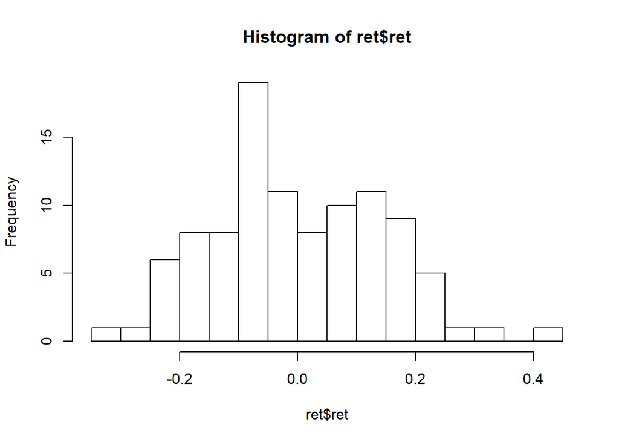

```r
s = 100
mu = 0.000000082
sig = 0.00048
t=252*6.5*60
u=exp(sig)
d=1/u

p<-(exp(mu)-d)/(u-d)
ret<-rep(NA,length=100)
s<-rep(NA,length=t+1)

s[1]<-100

for(i in 1:100){

  path<-runif(t)

  for(j in 1:t){

    ifelse(path[j]<p,s[j+1]<-s[j]*u,s[j+1]<-s[j]*d)

  }

  ret[i]<-(s[length(s)]-100)/100

}


ret<-data.frame(ret)

hist(ret$ret, breaks=20)
```

```r
sdret<-sd(ret$ret)

sdret
```

```
## [1] 0.1452523
```